# linkET tutorial

Author

TigerZ

Published

2023-07-15

```r
library(linkET)
library(vegan)
library(dplyr)
library(ggplot2)
```

## 数据

```r
data("varechem", package = "vegan")
data("varespec", package = "vegan")
```

```r
knitr::kable(varechem)
```

|  | N | P | K | Ca | Mg | S | Al | Fe | Mn | Zn | Mo | Baresoil | Humdepth | pH |
| --- | --- | --- | --- | --- | --- | --- | --- | --- | --- | --- | --- | --- | --- | --- |
| 18 | 19.8 | 42.1 | 139.9 | 519.4 | 90.0 | 32.3 | 39.0 | 40.9 | 58.1 | 4.5 | 0.30 | 43.90 | 2.2 | 2.7 |
| 15 | 13.4 | 39.1 | 167.3 | 356.7 | 70.7 | 35.2 | 88.1 | 39.0 | 52.4 | 5.4 | 0.30 | 23.60 | 2.2 | 2.8 |
| 24 | 20.2 | 67.7 | 207.1 | 973.3 | 209.1 | 58.1 | 138.0 | 35.4 | 32.1 | 16.8 | 0.80 | 21.20 | 2.0 | 3.0 |
| 27 | 20.6 | 60.8 | 233.7 | 834.0 | 127.2 | 40.7 | 15.4 | 4.4 | 132.0 | 10.7 | 0.20 | 18.70 | 2.9 | 2.8 |
| 23 | 23.8 | 54.5 | 180.6 | 777.0 | 125.8 | 39.5 | 24.2 | 3.0 | 50.1 | 6.6 | 0.30 | 46.00 | 3.0 | 2.7 |
| 19 | 22.8 | 40.9 | 171.4 | 691.8 | 151.4 | 40.8 | 104.8 | 17.6 | 43.6 | 9.1 | 0.40 | 40.50 | 3.8 | 2.7 |
| 22 | 26.6 | 36.7 | 171.4 | 738.6 | 94.9 | 33.8 | 20.7 | 2.5 | 77.6 | 7.4 | 0.30 | 23.00 | 2.8 | 2.8 |
| 16 | 24.2 | 31.0 | 138.2 | 394.6 | 45.3 | 27.1 | 74.2 | 9.8 | 24.4 | 5.2 | 0.30 | 29.80 | 2.0 | 2.8 |
| 28 | 29.8 | 73.5 | 260.0 | 748.6 | 105.3 | 42.5 | 17.9 | 2.4 | 106.6 | 9.3 | 0.30 | 17.60 | 3.0 | 2.8 |
| 13 | 28.1 | 40.5 | 313.8 | 540.7 | 118.9 | 60.2 | 329.7 | 109.9 | 61.7 | 9.1 | 0.50 | 29.90 | 2.2 | 2.8 |
| 14 | 21.8 | 38.1 | 146.8 | 512.2 | 75.0 | 36.6 | 92.3 | 4.6 | 29.0 | 8.1 | 0.50 | 33.30 | 2.7 | 2.7 |
| 20 | 26.2 | 61.9 | 202.2 | 741.2 | 86.3 | 48.6 | 124.3 | 23.6 | 94.5 | 10.2 | 0.60 | 56.90 | 2.5 | 2.9 |
| 25 | 22.8 | 50.6 | 151.7 | 648.0 | 64.8 | 30.2 | 12.1 | 2.3 | 122.9 | 8.1 | 0.20 | 23.70 | 2.6 | 2.9 |
| 7 | 30.5 | 24.6 | 78.7 | 188.5 | 55.5 | 25.3 | 294.9 | 123.8 | 10.1 | 3.0 | 0.40 | 18.60 | 1.7 | 3.1 |
| 5 | 33.1 | 22.7 | 43.6 | 240.3 | 25.7 | 14.9 | 39.0 | 8.4 | 26.8 | 8.4 | 0.20 | 8.10 | 1.0 | 3.1 |
| 6 | 19.1 | 26.4 | 61.1 | 259.1 | 37.0 | 21.4 | 155.1 | 81.4 | 20.6 | 4.0 | 0.60 | 5.80 | 1.9 | 3.0 |
| 3 | 31.1 | 32.3 | 73.7 | 219.0 | 52.5 | 25.5 | 304.6 | 204.4 | 14.2 | 2.6 | 0.50 | 3.60 | 1.8 | 3.3 |
| 4 | 18.0 | 64.9 | 224.5 | 517.6 | 59.7 | 52.9 | 435.1 | 101.2 | 38.0 | 9.5 | 1.10 | 21.30 | 1.8 | 2.9 |
| 2 | 22.3 | 47.4 | 165.9 | 436.1 | 64.3 | 42.3 | 316.5 | 200.1 | 28.2 | 7.2 | 0.30 | 0.01 | 1.5 | 2.9 |
| 9 | 15.0 | 48.4 | 127.4 | 499.6 | 75.1 | 46.9 | 227.1 | 32.2 | 35.1 | 8.9 | 0.70 | 6.07 | 2.2 | 3.0 |
| 12 | 16.0 | 32.7 | 126.4 | 471.4 | 61.3 | 31.1 | 108.8 | 9.5 | 26.4 | 6.0 | 0.40 | 11.20 | 2.2 | 2.9 |
| 10 | 14.3 | 62.8 | 215.2 | 709.7 | 102.5 | 48.6 | 168.2 | 32.0 | 46.9 | 8.7 | 0.05 | 4.40 | 1.2 | 3.2 |
| 11 | 16.7 | 55.8 | 205.3 | 1169.7 | 126.3 | 35.9 | 253.6 | 96.4 | 25.1 | 8.2 | 0.05 | 7.60 | 1.1 | 3.6 |
| 21 | 21.0 | 26.5 | 104.4 | 484.8 | 74.4 | 22.2 | 35.8 | 5.9 | 27.5 | 5.3 | 0.20 | 56.00 | 2.5 | 3.0 |

```r
knitr::kable(varespec)
```

|  | Callvulg | Empenigr | Rhodtome | Vaccmyrt | Vaccviti | Pinusylv | Descflex | Betupube | Vacculig | Diphcomp | Dicrsp | Dicrfusc | Dicrpoly | Hylosple | Pleuschr | Polypili | Polyjuni | Polycomm | Pohlnuta | Ptilcili | Barbhatc | Cladarbu | Cladrang | Cladstel | Cladunci | Cladcocc | Cladcorn | Cladgrac | Cladfimb | … |
| --- | --- | --- | --- | --- | --- | --- | --- | --- | --- | --- | --- | --- | --- | --- | --- | --- | --- | --- | --- | --- | --- | --- | --- | --- | --- | --- | --- | --- | --- | --- |
| 18 | 0.55 | 11.13 | 0.00 | 0.00 | 17.80 | 0.07 | 0.00 | 0.00 | 1.60 | 2.07 | 0.00 | 1.62 | 0.00 | 0.00 | 4.67 | 0.02 | 0.13 | 0.00 | 0.13 | 0.12 | 0.00 | 21.73 | 21.47 | 3.50 | 0.30 | 0.18 | 0.23 | 0.25 | 0.25 | … |
| 15 | 0.67 | 0.17 | 0.00 | 0.35 | 12.13 | 0.12 | 0.00 | 0.00 | 0.00 | 0.00 | 0.33 | 10.92 | 0.02 | 0.00 | 37.75 | 0.02 | 0.23 | 0.00 | 0.03 | 0.02 | 0.00 | 12.05 | 8.13 | 0.18 | 2.65 | 0.13 | 0.18 | 0.23 | 0.25 | … |
| 24 | 0.10 | 1.55 | 0.00 | 0.00 | 13.47 | 0.25 | 0.00 | 0.00 | 0.00 | 0.00 | 23.43 | 0.00 | 1.68 | 0.00 | 32.92 | 0.00 | 0.23 | 0.00 | 0.32 | 0.03 | 0.00 | 3.58 | 5.52 | 0.07 | 8.93 | 0.00 | 0.20 | 0.48 | 0.00 | … |
| 27 | 0.00 | 15.13 | 2.42 | 5.92 | 15.97 | 0.00 | 3.70 | 0.00 | 1.12 | 0.00 | 0.00 | 3.63 | 0.00 | 6.70 | 58.07 | 0.00 | 0.00 | 0.13 | 0.02 | 0.08 | 0.08 | 1.42 | 7.63 | 2.55 | 0.15 | 0.00 | 0.38 | 0.12 | 0.10 | … |
| 23 | 0.00 | 12.68 | 0.00 | 0.00 | 23.73 | 0.03 | 0.00 | 0.00 | 0.00 | 0.00 | 0.00 | 3.42 | 0.02 | 0.00 | 19.42 | 0.02 | 2.12 | 0.00 | 0.17 | 1.80 | 0.02 | 9.08 | 9.22 | 0.05 | 0.73 | 0.08 | 1.42 | 0.50 | 0.17 | … |
| 19 | 0.00 | 8.92 | 0.00 | 2.42 | 10.28 | 0.12 | 0.02 | 0.00 | 0.00 | 0.00 | 0.00 | 0.32 | 0.02 | 0.00 | 21.03 | 0.02 | 1.58 | 0.18 | 0.07 | 0.27 | 0.02 | 7.23 | 4.95 | 22.08 | 0.25 | 0.10 | 0.25 | 0.18 | 0.10 | … |
| 22 | 4.73 | 5.12 | 1.55 | 6.05 | 12.40 | 0.10 | 0.78 | 0.02 | 2.00 | 0.00 | 0.03 | 37.07 | 0.00 | 0.00 | 26.38 | 0.00 | 0.00 | 0.00 | 0.10 | 0.03 | 0.00 | 6.10 | 3.60 | 0.23 | 2.38 | 0.17 | 0.13 | 0.18 | 0.20 | … |
| 16 | 4.47 | 7.33 | 0.00 | 2.15 | 4.33 | 0.10 | 0.00 | 0.00 | 0.00 | 0.00 | 1.02 | 25.80 | 0.23 | 0.00 | 18.98 | 0.00 | 0.02 | 0.00 | 0.13 | 0.10 | 0.00 | 7.13 | 14.03 | 0.02 | 0.82 | 0.15 | 0.05 | 0.22 | 0.22 | … |
| 28 | 0.00 | 1.63 | 0.35 | 18.27 | 7.13 | 0.05 | 0.40 | 0.00 | 0.20 | 0.00 | 0.30 | 0.52 | 0.20 | 9.97 | 70.03 | 0.00 | 0.08 | 0.00 | 0.07 | 0.03 | 0.00 | 0.17 | 0.87 | 0.00 | 0.05 | 0.02 | 0.03 | 0.07 | 0.10 | … |
| 13 | 24.13 | 1.90 | 0.07 | 0.22 | 5.30 | 0.12 | 0.00 | 0.00 | 0.00 | 0.07 | 0.02 | 2.50 | 0.00 | 0.00 | 5.52 | 0.00 | 0.02 | 0.00 | 0.03 | 0.25 | 0.07 | 23.07 | 23.67 | 11.90 | 0.95 | 0.17 | 0.05 | 0.23 | 0.18 | … |
| 14 | 3.75 | 5.65 | 0.00 | 0.08 | 5.30 | 0.10 | 0.00 | 0.00 | 0.00 | 0.00 | 0.00 | 11.32 | 0.00 | 0.00 | 7.75 | 0.00 | 0.30 | 0.02 | 0.07 | 0.00 | 0.00 | 17.45 | 1.32 | 0.12 | 23.68 | 0.22 | 0.50 | 0.15 | 0.23 | … |
| 20 | 0.02 | 6.45 | 0.00 | 0.00 | 14.13 | 0.07 | 0.00 | 0.00 | 0.47 | 0.00 | 0.85 | 1.87 | 0.08 | 1.35 | 13.73 | 0.07 | 0.05 | 0.00 | 0.12 | 0.00 | 0.00 | 6.80 | 11.22 | 0.05 | 4.75 | 0.03 | 0.12 | 0.22 | 0.18 | … |
| 25 | 0.00 | 6.93 | 0.00 | 0.00 | 10.60 | 0.02 | 0.10 | 0.02 | 0.05 | 0.07 | 14.02 | 10.82 | 0.00 | 0.02 | 28.77 | 0.00 | 6.98 | 0.13 | 0.00 | 0.22 | 0.00 | 6.00 | 2.25 | 0.00 | 0.80 | 0.12 | 0.57 | 0.17 | 0.15 | … |
| 7 | 0.00 | 5.30 | 0.00 | 0.00 | 8.20 | 0.00 | 0.05 | 0.00 | 8.10 | 0.28 | 0.00 | 0.45 | 0.03 | 0.00 | 0.10 | 0.00 | 0.25 | 0.00 | 0.03 | 0.00 | 0.00 | 35.00 | 42.50 | 0.28 | 0.35 | 0.08 | 0.20 | 0.25 | 0.18 | … |
| 5 | 0.00 | 0.13 | 0.00 | 0.00 | 2.75 | 0.03 | 0.00 | 0.00 | 0.00 | 0.00 | 0.00 | 0.25 | 0.03 | 0.00 | 0.03 | 0.18 | 0.65 | 0.00 | 0.00 | 0.00 | 0.00 | 18.50 | 59.00 | 0.98 | 0.28 | 0.23 | 0.23 | 0.23 | 0.10 | … |
| 6 | 0.30 | 5.75 | 0.00 | 0.00 | 10.50 | 0.10 | 0.00 | 0.00 | 0.00 | 0.00 | 0.00 | 0.85 | 0.00 | 0.00 | 0.05 | 0.03 | 0.08 | 0.00 | 0.00 | 0.08 | 0.00 | 39.00 | 37.50 | 11.30 | 3.45 | 0.18 | 0.20 | 0.25 | 0.25 | … |
| 3 | 0.03 | 3.65 | 0.00 | 0.00 | 4.43 | 0.00 | 0.00 | 0.00 | 1.65 | 0.50 | 0.00 | 0.55 | 0.00 | 0.00 | 0.05 | 0.00 | 0.00 | 0.00 | 0.03 | 0.03 | 0.00 | 8.80 | 29.50 | 55.60 | 0.25 | 0.08 | 0.25 | 0.25 | 0.15 | … |
| 4 | 3.40 | 0.63 | 0.00 | 0.00 | 1.98 | 0.05 | 0.05 | 0.00 | 0.03 | 0.00 | 0.00 | 0.20 | 0.00 | 0.00 | 1.53 | 0.00 | 0.10 | 0.00 | 0.05 | 0.00 | 0.00 | 15.73 | 20.03 | 28.20 | 0.73 | 0.10 | 0.15 | 0.13 | 0.10 | … |
| 2 | 0.05 | 9.30 | 0.00 | 0.00 | 8.50 | 0.03 | 0.00 | 0.00 | 0.00 | 0.00 | 0.00 | 0.03 | 0.00 | 0.00 | 0.75 | 0.00 | 0.03 | 0.00 | 0.00 | 0.03 | 0.00 | 0.48 | 24.50 | 75.00 | 0.20 | 0.00 | 0.03 | 0.03 | 0.05 | … |
| 9 | 0.00 | 3.47 | 0.00 | 0.25 | 20.50 | 0.25 | 0.00 | 0.00 | 0.00 | 0.25 | 0.00 | 0.38 | 0.25 | 0.00 | 4.07 | 0.00 | 0.25 | 0.00 | 0.25 | 0.25 | 0.00 | 0.46 | 4.00 | 84.30 | 0.25 | 0.25 | 0.25 | 0.25 | 0.25 | … |
| 12 | 0.25 | 11.50 | 0.00 | 0.00 | 15.80 | 1.20 | 0.00 | 0.00 | 0.00 | 0.00 | 0.25 | 0.25 | 0.00 | 0.00 | 6.00 | 0.00 | 0.00 | 0.00 | 0.25 | 0.00 | 0.00 | 3.60 | 14.60 | 63.30 | 1.30 | 0.00 | 0.25 | 0.25 | 0.25 | … |
| 10 | 0.25 | 11.00 | 0.00 | 0.00 | 11.90 | 0.25 | 0.00 | 0.00 | 0.00 | 0.00 | 0.00 | 0.25 | 0.25 | 0.00 | 0.67 | 0.00 | 0.25 | 0.00 | 0.25 | 0.00 | 0.00 | 1.30 | 8.70 | 84.30 | 0.25 | 0.25 | 0.25 | 0.00 | 0.25 | … |
| 11 | 2.37 | 0.67 | 0.00 | 0.00 | 12.90 | 0.80 | 0.00 | 0.00 | 0.00 | 0.00 | 0.00 | 0.25 | 0.25 | 0.00 | 17.70 | 0.25 | 0.25 | 0.00 | 0.25 | 0.67 | 0.00 | 9.67 | 29.80 | 31.80 | 2.53 | 0.25 | 0.25 | 0.25 | 0.00 | … |
| 21 | 0.00 | 16.00 | 4.00 | 15.00 | 25.00 | 0.25 | 0.50 | 0.25 | 0.00 | 0.00 | 0.25 | 0.25 | 3.00 | 0.00 | 2.00 | 0.00 | 0.25 | 0.25 | 0.25 | 10.00 | 3.00 | 0.70 | 4.70 | 10.90 | 0.25 | 0.00 | 0.05 | 0.25 | 0.25 | … |

## Mantel test 分析

```r
mantel <- mantel_test(varespec, varechem,
                      spec_select = list(Spec01 = 1:7,
                                         Spec02 = 8:18,
                                         Spec03 = 19:37,
                                         Spec04 = 38:44)) %>%
  mutate(rd = cut(r, breaks = c(-Inf, 0.2, 0.4, Inf),
                  labels = c("< 0.2", "0.2 - 0.4", ">= 0.4")),
         pd = cut(p, breaks = c(-Inf, 0.01, 0.05, Inf),
                  labels = c("< 0.01", "0.01 - 0.05", ">= 0.05")))
```

```
`mantel_test()` using 'bray' dist method for 'spec'.
```

```
`mantel_test()` using 'euclidean' dist method for 'env'.
```

```r
spec_select = list(Spec01 = 1:7,
                   Spec02 = 8:18,
                   Spec03 = 19:37,
                   Spec04 = 38:44)
```

这语句代表的是，将矩阵 varespec 按照列进行分类，其中 1-7 分为第一类，8-18 分为第二类依次类推。后面可以根据自己的数据进行灵活应用修改，比如说只有四列数据就想分成四类则可以写成：

```r
spec_select = list(Y1 = 1,
                   Y2 = 2,
                   Y3 = 3,
                   Y4 = 4 )
```

```r
mutate(rd = cut(r, breaks = c(-Inf, 0.2, 0.4, Inf),
                labels = c("< 0.2", "0.2 - 0.4", ">= 0.4")),
       pd = cut(p, breaks = c(-Inf, 0.01, 0.05, Inf),
                labels = c("< 0.01", "0.01 - 0.05", ">= 0.05")))
```

mutate 将 Mantel test 运算结果进行分类，rd 将 r 值分为 c(“< 0.2”, “0.2 - 0.4”, “>= 0.4”) 三类，Label 是标签的意思。pd 将 p 值分为 c(“< 0.01”, “0.01 - 0.05”, “>= 0.05”) 三类。

## 绘图

### 热图的绘制

- correlate(varechem) 计算 varechem 矩阵的相关性矩阵
- type = “lower” 保留下三角，“upper” 保留上三角
- diag = FALSE 去除对角线，TRUE 保留对角线
- geom_square () 热图里以方块进行填充

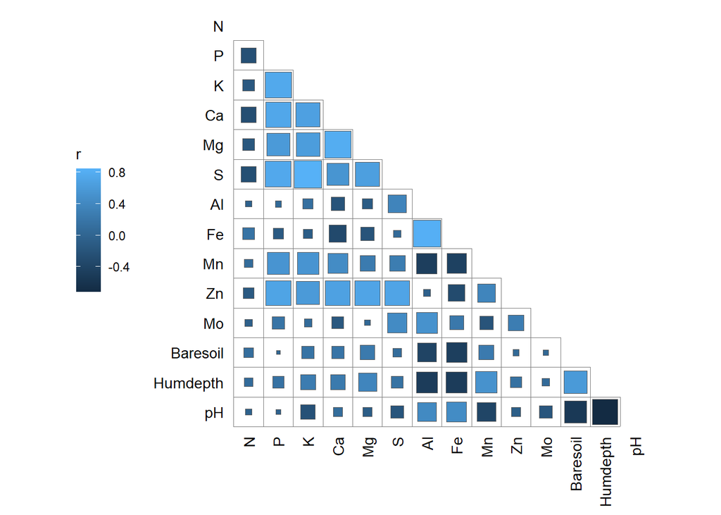

```r
qcorrplot(correlate(varechem), type = "lower", diag = FALSE) +
  geom_square()
```

### 绘制 Mantel test

- geom_couple() 中 colour 是指将上面代码中的 pd 也就是 p 值用连线的颜色表示，size 表示上面代码中的 rd 也就是 R 值用连线的粗细表示。
- data=mantel 数据来源为 mantel 对象。
- curvature 设置曲线弯曲量的数值，值越大弯曲越大。
- node.colour 设置 node 的 colour，前一个颜色为外部 node 颜色，后一个颜色为内部 node 颜色
- node.fill 设置 node 的 fill，前一个为外部，后一个为内部
- node.size 设置 node 的 size，前一个为外部，后一个为内部

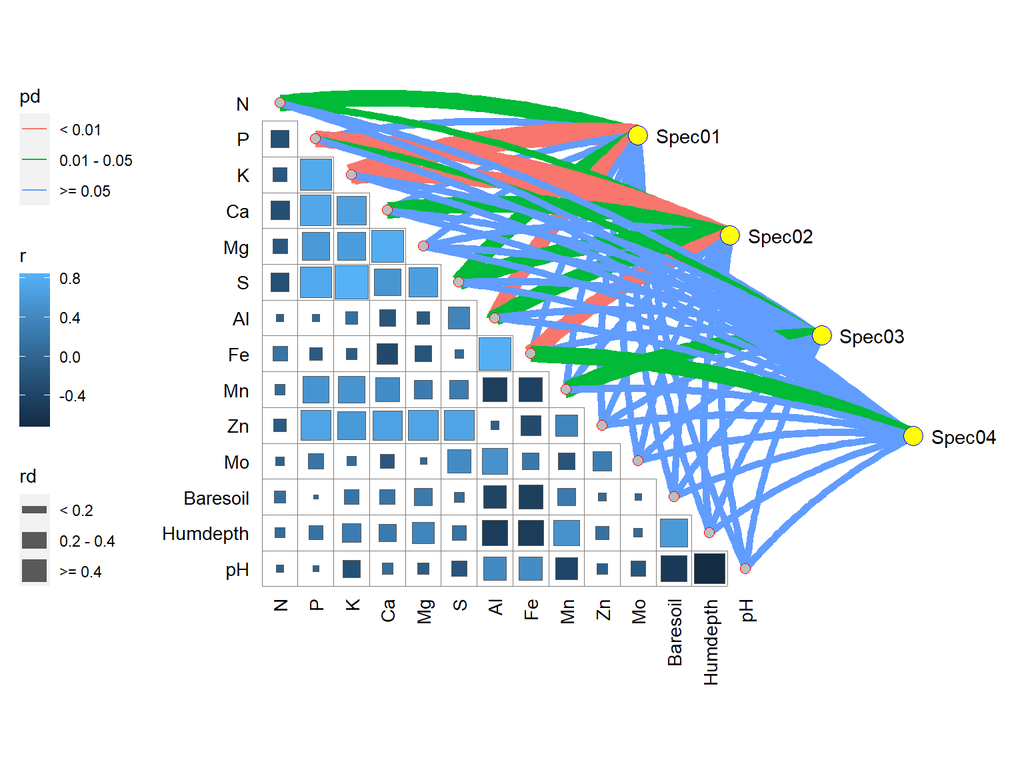

```r
qcorrplot(correlate(varechem), type = "lower", diag = FALSE) +
  geom_square() +
  geom_couple(aes(colour = pd, size = rd),
              data = mantel,
              curvature = 0.1,
              node.colour = c("blue","red"),
              node.fill = c("yellow","grey"),
              node.size = c(5,2.5))
```

### 美化图形

- scale_fill_gradientn() 设置热图的颜色、图例
- scale_size_manual() 设置线条的 size
- scale_colour_manual() 设置线条的 colour
- guides() 设置图例

```r
p <- qcorrplot(correlate(varechem), type = "lower", diag = FALSE) +
  geom_square() +
  geom_couple(aes(colour = pd, size = rd),
              data = mantel,
              curvature = 0.1,
              node.colour = c("blue","red"),
              node.fill = c("yellow","grey"),
              node.size = c(5,2.5)) +
  scale_fill_gradientn(colours = RColorBrewer::brewer.pal(11, "RdBu"),
                       limits = c (-1, 1),
                       breaks = seq (-1,1,0.5)) +
  scale_size_manual(values = c(0.5, 1, 2)) +
  scale_colour_manual(values = color_pal(3)) +
  guides(size = guide_legend(title = "Mantel's r",
                             override.aes = list(colour = "grey35"),
                             order = 2),
         colour = guide_legend(title = "Mantel's p",
                               override.aes = list(size = 3),
                               order = 1),
         fill = guide_colorbar(title = "Pearson's r", order = 3))
```

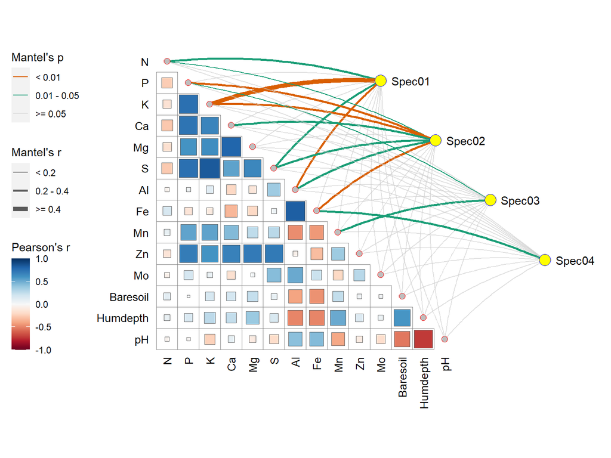

```r
p
```